# Reproducible Research: Peer Assessment 1

Hi! Now we are going the start this assignment choosing a library for our plots.

**0. Choosing library plot**

```r
library(ggplot2)
library(scales)
library(Hmisc)
```

### Loading and preprocessing the data

**1. We need to unzip the file “activity.zip”:**

```r
temp<-"C:/Users/Leticia/Desktop/RepData_PeerAssessment1/activity.zip"
unzip(temp)
```

**2. Now we can read the csv file using read.csv:**

```r
activity<-read.csv("activity.csv")
```

Ok! So, let’s do some data analysis!

### What is mean total number of steps taken per day?

**3. Computes the number of steps per day in *stepsByDay* variable:**

```r
stepsByDay <- tapply(activity$steps, activity$date, sum, na.rm=TRUE)
```

**4. Make an histogram:**

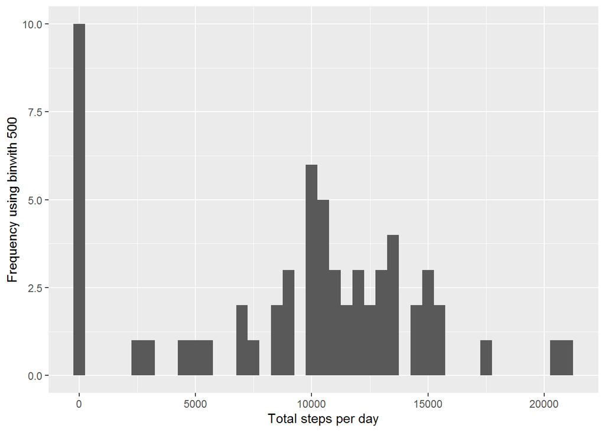

```r
qplot(stepsByDay, xlab='Total steps per day', ylab='Frequency using binwith 500', binwidth=500)
```

**5. Calculate and report the mean and median total number of steps taken per day.**

```r
stepsByDayMean <- mean(stepsByDay)
stepsByDayMedian <- median(stepsByDay)
```

- Mean: 9354.2295082
- Median: 10395

### What is the average daily activity pattern?

```r
averageStepsPerTimeBlock <- aggregate(x=list(meanSteps=activity$steps), by=list(interval=activity$interval), FUN=mean, na.rm=TRUE)
```

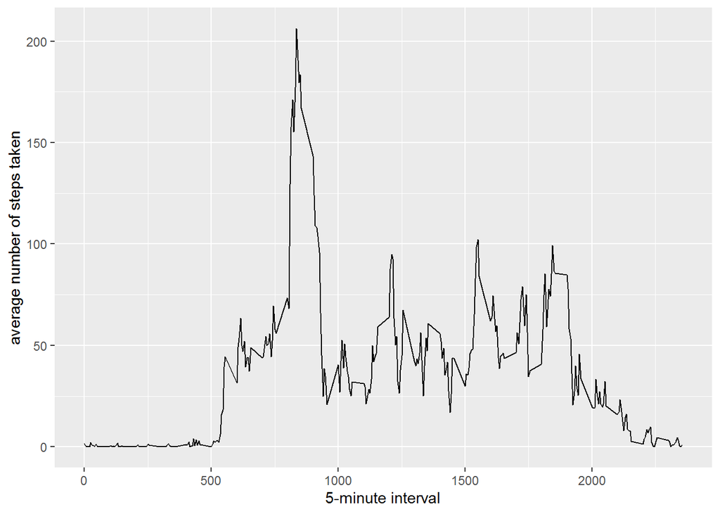

```r
ggplot(data=averageStepsPerTimeBlock, aes(x=interval, y=meanSteps)) +
    geom_line() +
    xlab("5-minute interval") +
    ylab("average number of steps taken")
```

### Which 5-minute interval, on average across all the days in the dataset, contains the maximum number of steps?

```r
mostSteps <- which.max(averageStepsPerTimeBlock$meanSteps)
timeMostSteps <-  gsub("([0-9]{1,2})([0-9]{2})", "\\1:\\2", averageStepsPerTimeBlock[mostSteps,'interval'])
```

- Most Steps at: 8:35

### Imputing missing values

```r
numMissingValues <- length(which(is.na(activity$steps)))
```

- Number of missing values: 2304

**10. Devise a strategy for filling in all of the missing values in the dataset.**

**11. Create a new dataset that is equal to the original dataset but with the missing data filled in.**

```r
activityImputed <- activity
activityImputed$steps <- impute(activity$steps, fun=mean)
```

*12. Make a histogram of the total number of steps taken each day.*

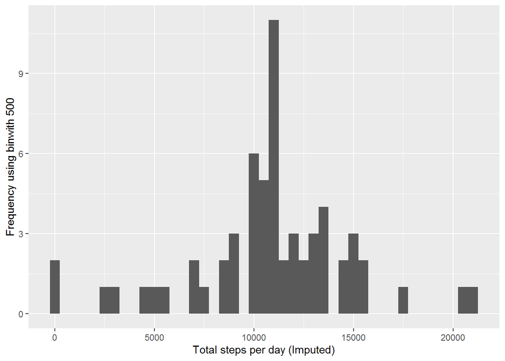

```r
stepsByDayImputed <- tapply(activityImputed$steps, activityImputed$date, sum)
qplot(stepsByDayImputed, xlab='Total steps per day (Imputed)', ylab='Frequency using binwith 500', binwidth=500)
```

```r
stepsByDayMeanImputed <- mean(stepsByDayImputed)
stepsByDayMedianImputed <- median(stepsByDayImputed)
```